# Mhd Haekal Hakim_Tugas Praktikum 7

Mhd Haekal Hakim

2025-10-02

## Library

```r
library(tseries)
```

```r
library(ggplot2)
library(tsibble)
library(MASS)
library(readxl)
library(forecast)
library(TSA)
library(TTR)
library(aTSA)
library(graphics)
```

## Data

```r
## Baca Data
data <- read_excel("C:/Users/mhdha/OneDrive/Dokumen/IPB/Semester 5/MPDW/JKSE_Close_Weekly.xlsx")

data1 <- data[518:775, ]
data1
```

```
## # A tibble: 258 × 2
##    Date                Close
##    <dttm>              <dbl>
##  1 2015-08-17 00:00:00 4336.
##  2 2015-08-24 00:00:00 4446.
##  3 2015-08-31 00:00:00 4415.
##  4 2015-09-07 00:00:00 4360.
##  5 2015-09-14 00:00:00 4380.
##  6 2015-09-21 00:00:00 4209.
##  7 2015-09-28 00:00:00 4208.
##  8 2015-10-05 00:00:00 4589.
##  9 2015-10-12 00:00:00 4522.
## 10 2015-10-19 00:00:00 4653.
## # ℹ 248 more rows
```

### Mengambil Data Train

```r
n <- nrow(data1)              # jumlah data = 258
n_train <- floor(0.8 * n)  # train = 206
dt_rg <- data1$`Close`[1:n_train] |> ts()
```

### Membuat Plot Data Time Series

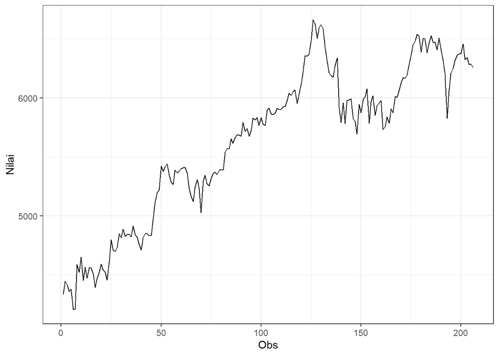

```r
dt_rg |> as_tsibble() |>
  ggplot(aes(x = index, y = value)) +
  geom_line() + theme_bw() +
  xlab("Obs") + ylab("Nilai")
```

Berdasarkan plot time series tersebut, terlihat bahwa data tidak stasioner dalam rataan, ditandai dengan adanya trend pada data dan tidak stasioner dalam ragam, ditandai dengan adanya perbedaan lebar pita pada plot

#### Uji ACF

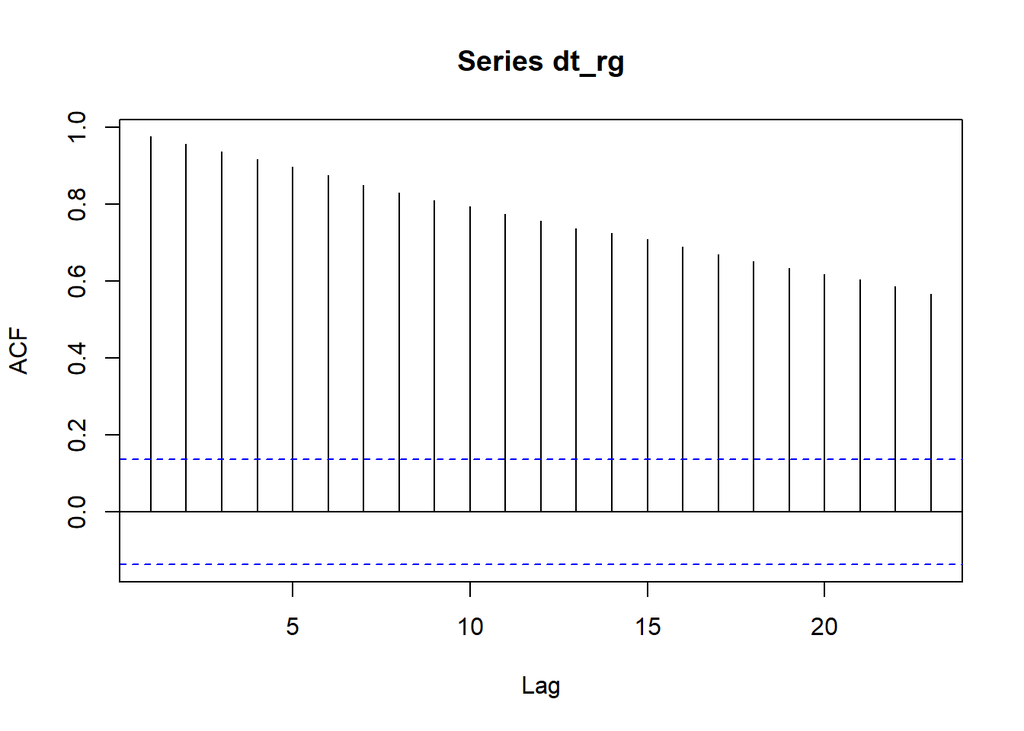

```r
acf(dt_rg)
```

Berdasarkan plot ACF, terlihat bahwa plot ACF pada data tersebut menurun secara perlahan (*tails off slowly*) yang menandakan data tidak stasioner dalam rataan

#### Uji ADF

```r
adf.test(dt_rg)
```

```
## Augmented Dickey-Fuller Test
## alternative: stationary
##
## Type 1: no drift no trend
##      lag  ADF p.value
## [1,]   0 1.11   0.927
## [2,]   1 1.24   0.944
## [3,]   2 1.36   0.955
## [4,]   3 1.48   0.964
## [5,]   4 1.43   0.960
## Type 2: with drift no trend
##      lag   ADF p.value
## [1,]   0 -1.80   0.404
## [2,]   1 -1.63   0.473
## [3,]   2 -1.66   0.463
## [4,]   3 -1.74   0.429
## [5,]   4 -1.75   0.427
## Type 3: with drift and trend
##      lag   ADF p.value
## [1,]   0 -2.65   0.303
## [2,]   1 -2.25   0.469
## [3,]   2 -2.09   0.537
## [4,]   3 -2.00   0.573
## [5,]   4 -2.05   0.554
## ----
## Note: in fact, p.value = 0.01 means p.value <= 0.01
```

$H_0$: Data tidak stasioner dalam rataan

$H_1$: Data stasioner dalam rataan

### Uji Box-cox

```r
# Bikin Index
index <- seq_along(dt_rg)
```

```r
# Buat Data Supaya Positif
shift_val <- abs(min(dt_rg)) + 1
dt_rg_shift <- dt_rg + shift_val
```

```r
# Regresi Linear untuk Box-Cox
lm_bc <- lm(dt_rg_shift ~ index)
```

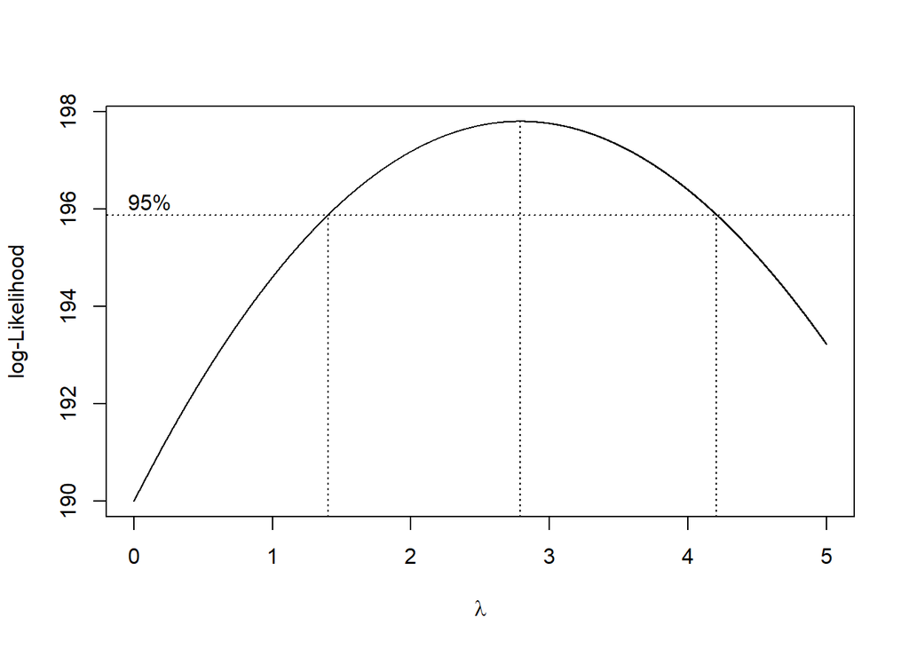

```r
# Uji Box-Cox
bc <- boxcox(lm_bc, lambda = seq(0, 5, by = 0.001))
```

```r
# Cari Lambda Optimum
lambda_opt <- bc$x[which.max(bc$y)]
ci_lambda <- bc$x[bc$y > max(bc$y) - 0.5 * qchisq(0.95, 1)]

cat("Lambda Optimum:", lambda_opt, "\n")
```

```
## Lambda Optimum: 2.788
```

```r
cat("95% CI Lambda:", min(ci_lambda), "-", max(ci_lambda), "\n")
```

```
## 95% CI Lambda: 1.402 - 4.206
```

### Transformasi

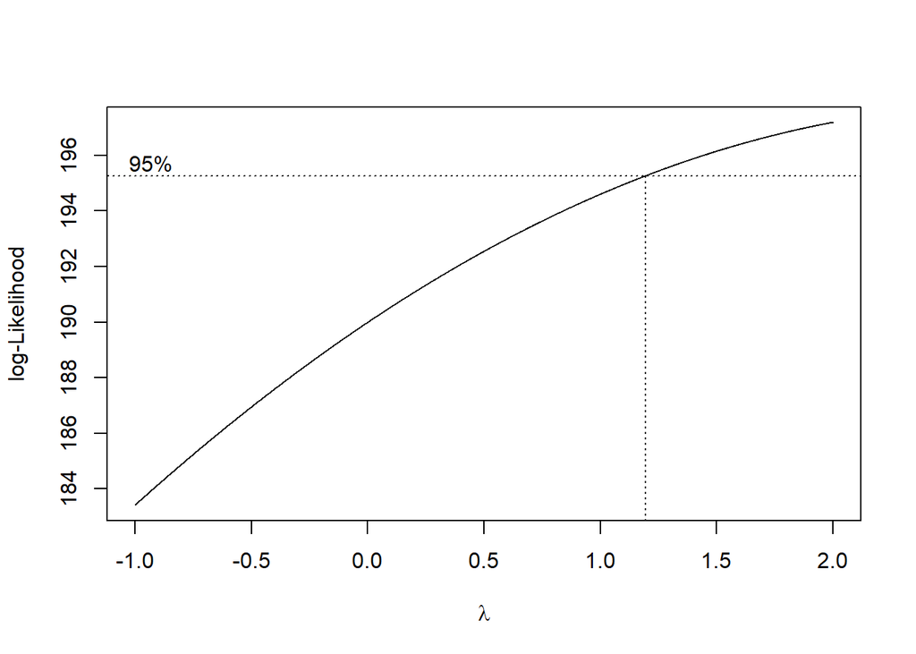

```r
# --- Transformasi Box-Cox ---
# Pastikan semua nilai positif
shift_val <- abs(min(dt_rg)) + 1
dt_shift <- dt_rg + shift_val

# Regresi linear untuk uji Box-Cox
lm_bc <- lm(dt_shift ~ seq_along(dt_shift))

# Uji Box-Cox dengan rentang lambda yang cukup luas
bc <- boxcox(lm_bc, lambda = seq(-1, 2, 0.001))
```

```r
# Ambil lambda optimum
lambda_opt <- bc$x[which.max(bc$y)]
cat("Lambda optimum Box-Cox:", lambda_opt, "\n")
```

```
## Lambda optimum Box-Cox: 2
```

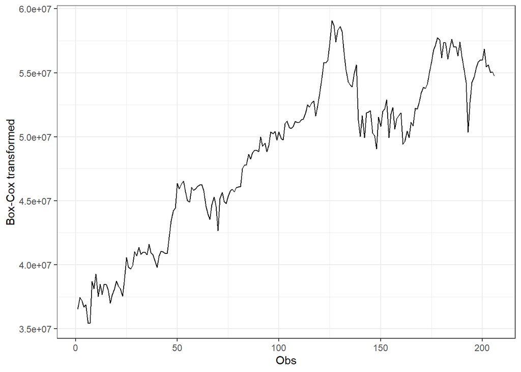

```r
# Transformasi Box-Cox
dt_bc <- BoxCox(dt_shift, lambda = lambda_opt)

# Plot hasil transformasi
dt_bc |> as_tsibble() |>
  ggplot(aes(x = index, y = value)) +
  geom_line() + theme_bw() +
  xlab("Obs") + ylab("Box-Cox transformed")
```

### Differencing

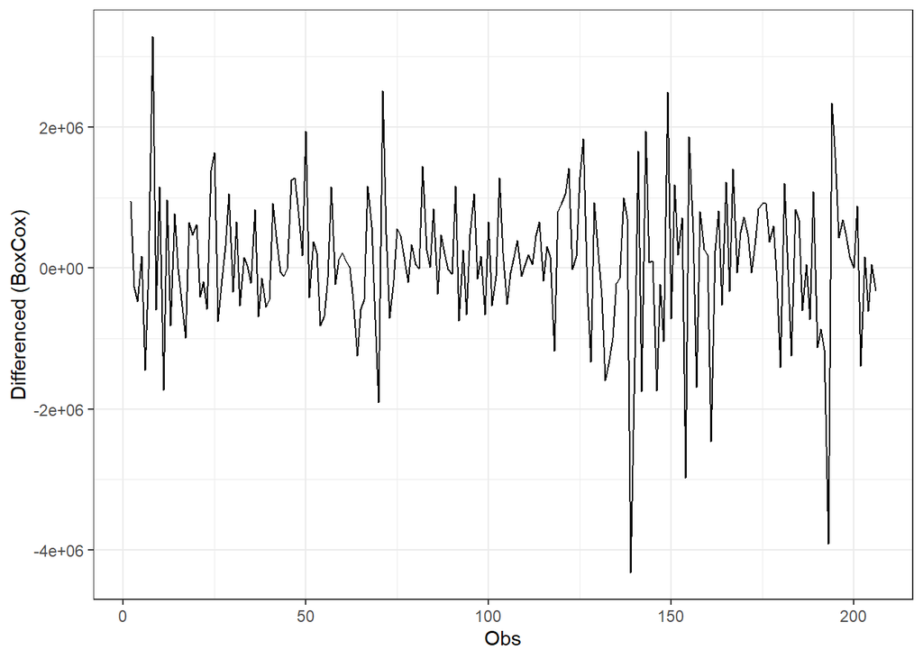

```r
# Differencing setelah transformasi
dt_diff <- diff(dt_bc, differences = 1)

# Plot
dt_diff |> as_tsibble() |>
  ggplot(aes(x = index, y = value)) +
  geom_line() + theme_bw() +
  xlab("Obs") + ylab("Differenced (BoxCox)")
```

#### Cek ACF dan ADF

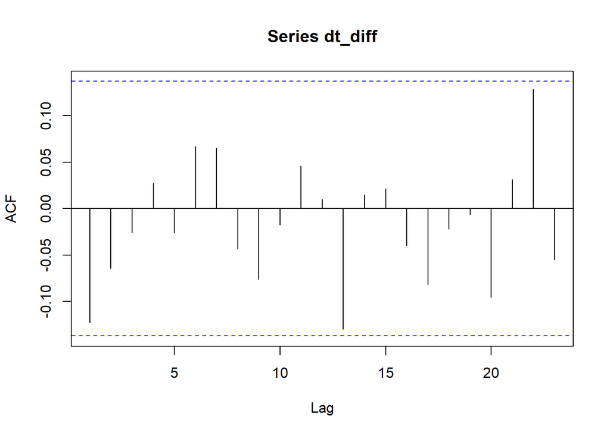

```r
acf(dt_diff)
```

Berdasarkan plot ACF, terlihat bahwa plot ACF pada data tersebut berada dalam rentang yang menandakan bahwa data stasioner dalam rataan

```r
adf.test(dt_diff)
```

```
## Augmented Dickey-Fuller Test
## alternative: stationary
##
## Type 1: no drift no trend
##      lag    ADF p.value
## [1,]   0 -16.01    0.01
## [2,]   1 -11.35    0.01
## [3,]   2  -9.09    0.01
## [4,]   3  -7.40    0.01
## [5,]   4  -6.60    0.01
## Type 2: with drift no trend
##      lag    ADF p.value
## [1,]   0 -16.10    0.01
## [2,]   1 -11.48    0.01
## [3,]   2  -9.26    0.01
## [4,]   3  -7.59    0.01
## [5,]   4  -6.84    0.01
## Type 3: with drift and trend
##      lag    ADF p.value
## [1,]   0 -16.10    0.01
## [2,]   1 -11.50    0.01
## [3,]   2  -9.30    0.01
## [4,]   3  -7.64    0.01
## [5,]   4  -6.93    0.01
## ----
## Note: in fact, p.value = 0.01 means p.value <= 0.01
```

$H_0$: Data tidak stasioner dalam rataan

$H_1$: Data stasioner dalam rataan

Berdasarkan uji ADF tersebut, didapat p-value sebesar 0.01 yang lebih kecil dari taraf nyata 5% dan menandakan bahwa data stasioner dalam rataan. Hal ini sesuai dengan hasil eksplorasi menggunakan plot time series dan plot ACF.

## Spesifikasi Model

```r
par(mfrow = c(1,2))
```

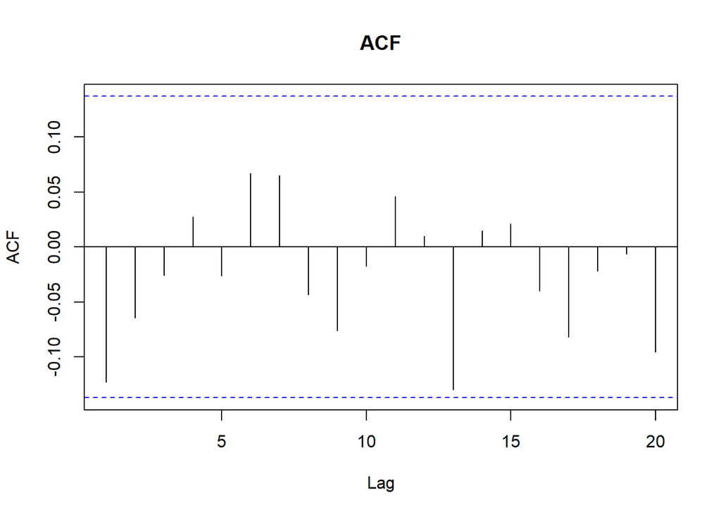

```r
acf(dt_diff, main ="ACF", lag.max=20)
```

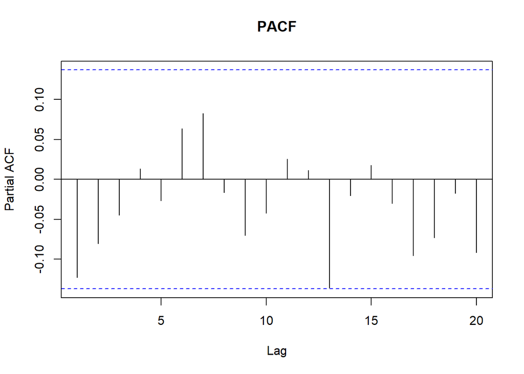

```r
pacf(dt_diff, main="PACF", lag.max=20)
```

```r
par(mfrow = c(1,1))
```

```r
eacf(dt_diff)
```

```
## AR/MA
##   0 1 2 3 4 5 6 7 8 9 10 11 12 13
## 0 o o o o o o o o o o o  o  o  o
## 1 x o o o o o o o o o o  o  o  o
## 2 x o o o o o o o o o o  o  o  o
## 3 x x x o o o o o o o o  o  o  o
## 4 x o o x o o o o o o o  o  o  o
## 5 x o x x o o o o o o o  o  o  o
## 6 x x x x o x o o o o o  o  o  o
## 7 x x x o x x o o o o o  o  o  o
```

Menggunakan plot EACF, dapat diambil beberapa model dengan melihat ujung segitiga yang terbentuk, antara lain ARIMA(0,0,0), ARIMA(1,0,1), ARIMA(2,0,2), ARIMA(3,0,3), ARIMA(4,0,4), dan ARIMA(6,0,6).